# 소셜 네트워크 분석 기말 보고서

박규훤, 소다영, 윤성연

2020 7 1

## 주제

- 특정 감독이 어떤 배우와 많은 영화를 찍었고, 그 사람들이 어떤 특징을 가지는지 분석
- 감독과 배우, 배우와 배우 사이의 캐미를 확인
- 비슷한 상황의 감독이 선택한 배우들의 성향, 및 배우들의 조합 확인

## 데이터

### 출처

- KOBIS (영화관 입장권 통합 전산망)

  [`http://www.kobis.or.kr/kobis/business/mast/mvie/searchMovieList.do`](http://www.kobis.or.kr/kobis/business/mast/mvie/searchMovieList.do)

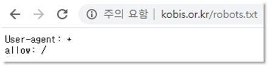

  로봇 배제 표준

### 소개

- KOBIS의 전국 영화 박스오피스, 영화 별 상세 정보, 관계자(감독, 주연 배우) 정보

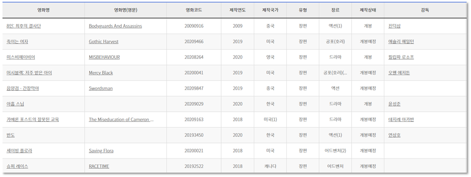

  박스오피스

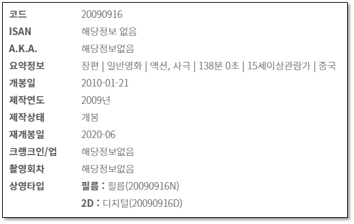

  영화 상세 정보

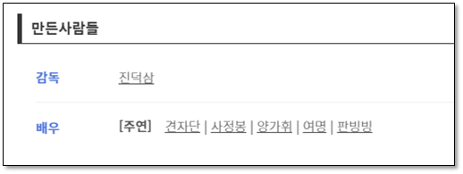

  관계자 정보

### 크롤링

- Python을 이용하여 크롤링 진행 (crawling.ipynb 파일 별첨)
- 빈 값 및 영화 모음 등에 대해 간단한 전처리 진행

```r
# 빈 값 및 영화 모음 등에 대한 전처리

Sys.setlocale('LC_ALL', 'C')
movie <- read.csv('movie_list.csv', encoding = 'UTF-8')
actor <- read.csv('staff_list.csv', encoding = 'UTF-8')
Sys.setlocale('LC_ALL', 'korean')

movie[str_detect(movie$genre,'.+분.+초$'),]$genre <- ''
movie[str_detect(movie$country,'.+분.+초$'),]$country <- ''
movie <- movie[!str_detect(movie$genre,'기타'),]
movie <- movie[movie$genre != '',]
actor <- actor[!is.na(actor$person_id),]

write.csv(movie, 'pre_movie.csv', row.names = F, fileEncoding = 'UTF-8')
write.csv(actor, 'pre_actor.csv', row.names = F, fileEncoding = 'UTF-8')
```

### 데이터 예시

```r
movie <- read.csv('pre_movie.csv', encoding = 'UTF-8', stringsAsFactors = F)
staff <- read.csv('pre_actor.csv', encoding = 'UTF-8', stringsAsFactors = F)
```

```
##                           title                    title_en     code status
## 1           겁쟁이 페달: 리로드    Yowamushi Pedal: Re:ROAD 20151005   개봉
## 2         겁쟁이 페달: 리라이드    Yowamushi Pedal: Re:RIDE 20151004   개봉
## 3          겁쟁이 페달: 더 무비  Yowamushi Pedal: The movie 20159965   개봉
## 4    겁쟁이 페달: 스페어 바이크 Yowamushi Pedal: SPARE BIKE 20163464   개봉
## 5 킬러의 보디가드 무삭제 특별판      The Hitman's Bodyguard 20189987   개봉
## 6                   날씨의 아이         Weathering With You 20190280   개봉
##   country                         genre       open
## 1    일본                    애니메이션 2016-01-14
## 2    일본                    애니메이션 2016-01-14
## 3    일본                    애니메이션 2016-01-14
## 4    일본                    애니메이션 2016-11-17
## 5    미국                   액션,코미디 2018-09-12
## 6    일본 애니메이션,판타지,멜로/로맨스 2019-10-30
```

```
##   movie_id person_category       person_name person_id
## 1 20151005        director   나베시마 오사무  10006891
## 2 20151004        director   나베시마 오사무  10006891
## 3 20159965        director 나가누마 노리히로  10057861
## 4 20163464        director   나베시마 오사무  10006891
## 5 20189987        director       패트릭 휴즈  20136404
## 6 20189987           actor   라이언 레이놀즈  10014018
```

### 개요

- 기간: 2010. 01. 01 ~ 2019. 12. 31
- 영화 데이터
  - 75개 국가, 20개 장르
  - 11880 x 7
- 관계자 데이터
  - 11738개 영화, 16706명 관계자
  - 35699 x 4

## 전처리

### 장르 분리

- 앞서 보인 영화 데이터와 같이, 한 영화가 다양한 장르에 포함되어 있음
- 따라서 단일 장르로 구성된 여러개의 영화 데이터로 재구성 과정이 필요

```r
movie <- movie %>% mutate(genre = strsplit(genre, ',')) %>% unnest(genre)
```

### 관계자 데이터 재구성

- 영화별 함께 출연 또는 작업한 관계자 사이의 연결을 데이터 프레임으로 재구성
- 감독과 주연배우 분리

  ```r
  actor <- staff %>% filter(person_category == 'actor')
  director <- staff %>% filter(person_category == 'director')
  ```

- 감독 - 배우 데이터
  - 영화 별 각 감독과 각 주연 배우 사이의 연결을 표현

  ```r
  director_data <- merge(director[c('movie_id', 'person_id')], actor[c('movie_id', 'person_id')], by='movie_id')
  director_data['person_id.x'] <- paste0('D', director_data[['person_id.x']])
  director_data['person_id.y'] <- paste0('A', director_data[['person_id.y']])
  ```

  ```
  ##   movie_id person_id.x person_id.y
  ## 1 19398001   D10033202   A10068907
  ## 2 19538011   D10050769   A10073138
  ## 3 19538011   D10050769   A20126569
  ## 4 19618009   D10032825   A10067252
  ## 5 19618009   D10032825   A10050206
  ## 6 19648012   D10019986   A10067700
  ```

- 배우 - 배우 데이터
  - 영화 별 각 주연배우 사이의 연결을 표현

  ```r
  movie_temp <- unique(actor[1])[[1]]
  actor_comb <- data.frame()
  for (j in 1:length(movie_temp)) {
    tmp <- actor[actor$movie_id==movie_temp[j],4]
    if (length(tmp) > 1) {
      actor_comb <- rbind(actor_comb, data.frame(movie_id=movie_temp[j], t(combn(tmp,2))))
    }
  }
  ```

  ```
  ##   movie_id       X1       X2
  ## 1 20189987 10014018 10034095
  ## 2 20190280 10029888 10006733
  ## 3 20190280 10029888 10050055
  ## 4 20190280 10029888 20191807
  ## 5 20190280 10029888 20205108
  ## 6 20190280 10029888 20307513
  ```

## 네트워크 생성

- 애니메이션, 액션, 코미디 등 20개의 장르와 통합 데이터에 대해, 각각 감독 - 배우 네트워크(이하 Director 네트워크, D네트워크)와 배우 - 배우 네트워크(이하 Actor 네트워크, A 네트워크) 생성

```r
graph_names <- c('d_animation', 'a_animation',
               'd_action', 'a_action',
               'd_comedy', 'a_comedy',
               'd_fanta', 'a_fanta',
               'd_melo', 'a_melo',
               'd_drama', 'a_drama',
               'd_mystery', 'a_mystery',
               'd_adventure', 'a_adventure',
               'd_thriller', 'a_thriller',
               'd_crime', 'a_crime',
               'd_family', 'a_family',
               'd_horor', 'a_horor',
               'd_scifi', 'a_scifi',
               'd_musical', 'a_musical',
               'd_war', 'a_war',
               'd_doc', 'a_doc',
               'd_hist', 'a_hist',
               'd_ero', 'a_ero',
               'd_show', 'a_show',
               'd_western', 'a_western')

categories <- c("애니메이션",
                "액션",
                "코미디",
                "판타지",
                "멜로/로맨스",
                "드라마",
                "미스터리",
                "어드벤처",
                "스릴러",
                "범죄",
                "가족",
                "공포(호러)",
                "SF",
                "뮤지컬",
                "전쟁",
                "다큐멘터리",
                "사극",
                "성인물(에로)",
                "공연",
                "서부극(웨스턴)")

# 네트워크 생성
for (i in 1:length(categories)) {
  staff_temp <- director_data[director_data$movie_id %in% movie[movie$genre == categories[i], ][['code']],]
  graph_temp <- graph_from_data_frame(staff_temp[2:3], directed=F)
  assign(graph_names[i*2-1], graph_temp)

  actor_temp <- actor_comb[actor_comb$movie_id %in% movie[movie$genre == categories[i],][['code']],]
  graph_temp2 <- graph_from_data_frame(actor_temp[2:3], directed=F)
  assign(graph_names[i*2], graph_temp2)
}

# 전체 네트워크 생성
staff_temp <- director_data
d_all <- graph_from_data_frame(staff_temp[2:3], directed=F)

actor_temp <- actor_comb
a_all <- graph_from_data_frame(actor_temp[2:3], directed=F)

graph_names <- c(graph_names, 'd_all', 'a_all')
```

## 시각화

- 생성된 42개의 네트워크에 대해 시각화

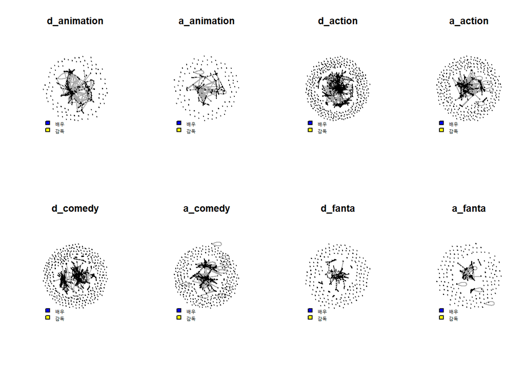

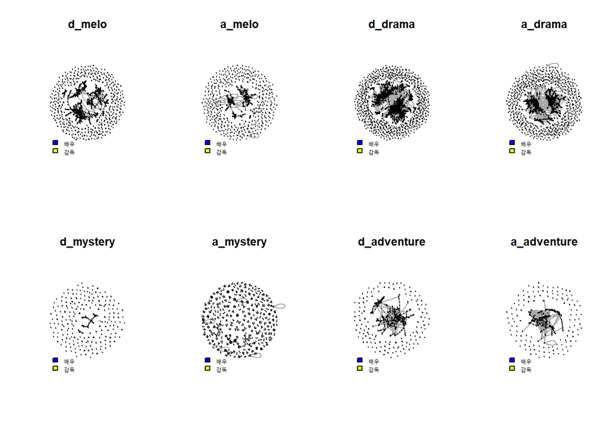

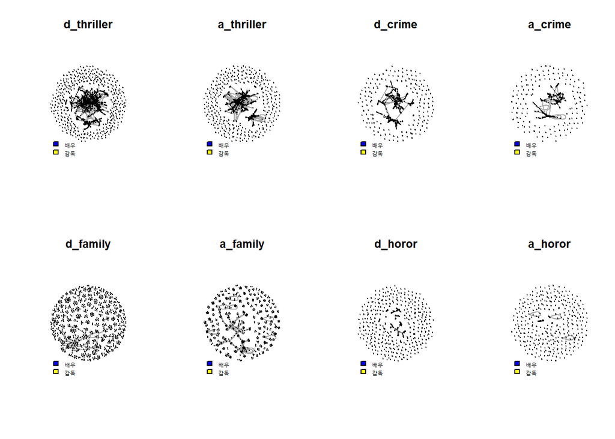

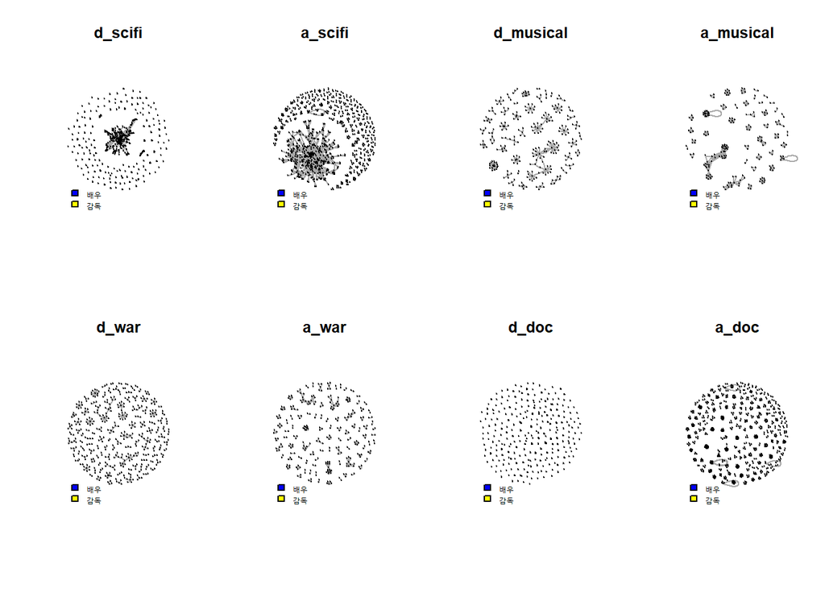

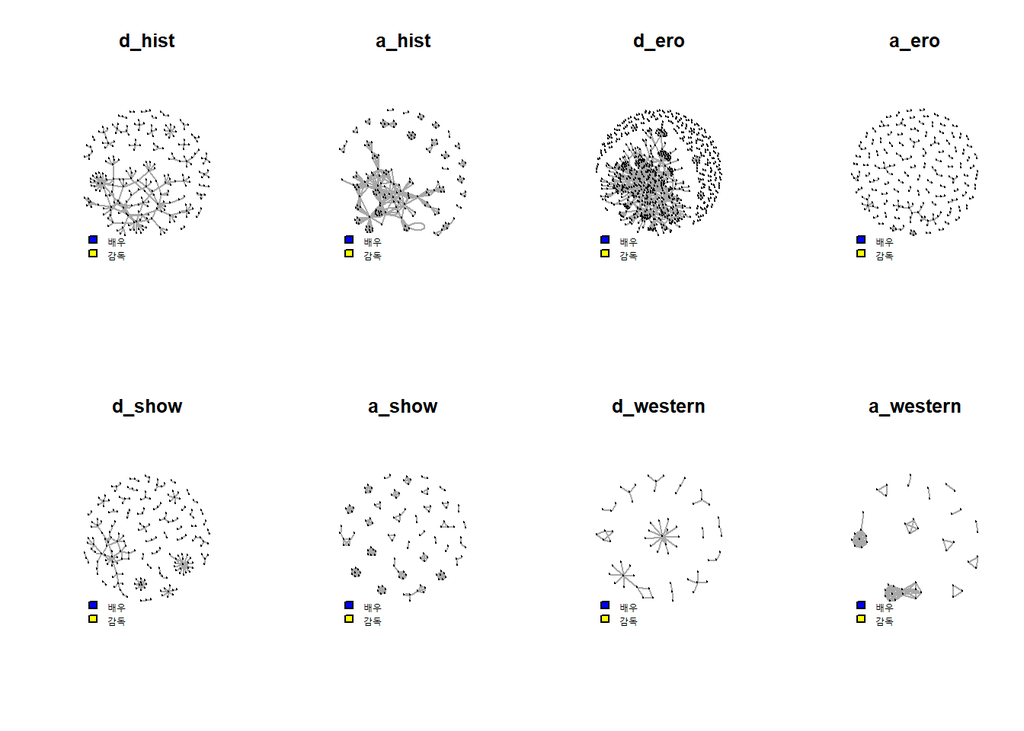

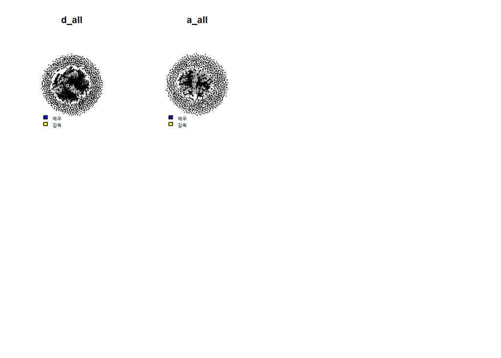

```r
par(mfrow=c(2,4))
for (s in graph_names) {
  g <- get(s)

  gubun <- str_sub(V(g)$name, 1, 1)
  colors <- ifelse(gubun=='D', 'yellow', 'blue')
  sizes <- ifelse(gubun=='D', 2, 1)
  plot(g, main=s,
       #layout=layout.kamada.kawai,
       vertex.size=sizes, vertex.color=colors, edge.arrow.size=0.01, vertex.label=NA)
  legend("bottomleft",c("배우","감독"),cex=0.7,fill=c('blue', 'yellow'),col=c('blue', 'yellow'),bty="n")
}
```

## 분석

```r
graph_stat <- data.frame()
graph_comp <- list()
for (s in graph_names) {
  g <- get(s)
  graph_stat <- rbind(graph_stat, data.frame(graph=s,
                                             vcount=vcount(g),
                                             ecount=ecount(g),
                                             density_a=edge_density(g, loops=F),
                                             density_d=ecount(g)/(sum(str_detect(names(V(g)), 'D'))*sum(str_detect(names(V(g)), 'A'))),
                                             dyad_mut=dyad_census(g)$mut,
                                             dyad_null=dyad_census(g)$null,
                                             triad_003=triad_census(g)[1],
                                             triad_201=triad_census(g)[11],
                                             transitivity=transitivity(g),
                                             centr=centr_degree(g)$centralization))
  graph_comp[s] <- components(g)
}
```

```
##          graph vcount ecount    density_a    density_d dyad_mut dyad_null
## 1  d_animation   1687   2861 0.0020117555 0.0047400510     2861   1419280
## 2  a_animation   1153   5313 0.0079999639          Inf     5313    658815
## 3     d_action   3834   5073 0.0006904050 0.0016191151     5073   7342788
## 4     a_action   2519   7775 0.0024515824          Inf     7775   3163646
## 5     d_comedy   3552   4123 0.0006537620 0.0015899428     4123   6302453
## 6     a_comedy   2465   6283 0.0020688997          Inf     6283   3030597
## 7      d_fanta   1493   1697 0.0015236430 0.0039714300     1697   1112081
## 8      a_fanta   1085   3574 0.0060775078          Inf     3574    584496
## 9       d_melo   3840   4254 0.0005771360 0.0013697148     4254   7366626
## 10      a_melo   2381   4180 0.0014752646          Inf     4180   2829210
## 11     d_drama   7880  10323 0.0003325360 0.0007750946    10323  31032937
## 12     a_drama   5021  12614 0.0010008958          Inf    12614  12590096
## 13   d_mystery   1161   1034 0.0015355371 0.0038571439     1034    672346
## 14   a_mystery    819   1295 0.0038660063          Inf     1295    333676
```

[output cut: 71 more lines]

### 노드 및 연결 수

- D네트워크와 A네트워크 모두 드라마 장르에서 최대 노드수와 최대 연결수를 보였고, 서부극(웨스턴) 장르에서 최소 노드수와 최소 연결수를 보임
  - 드라마 장르에 포함된 영화가 4198개로가 가장 많고, 한 영화의 다수의 주연 배우가 출연
  - 가운데에 응집성이 큰 노드 집합이 있으며, 외곽을 구성하는 노드들 또한 조밀하게 형성되어 있음
  - 서부극 장르의 영화는 24개로 가장 적고, 눈으로 셀 수 있을 정도의 노드 수를 구성하고 있으며, 노트간의 특징은 크게 찾아보기 어려움

### 밀도

- D네트워크는 이부 네트워크이기 때문에 ecount를 가능한 최대 엣지 수로 나누는 방식으로 밀도 계산 (density_d)
- D네트워크와 A네트워크 모두 규모가 가장 작은 서부극 장르가 가장 밀도가 높은 것으로 나타남
  - 규모가 작아 형성 가능한 엣지 수가 적기 때문에 밀도가 높게 나온 것으로 추정
- 이와 반대로, 가장 규모가 큰 드라마 장르의 밀도가 가장 낮은 것으로 나타남

### 추이성

- D네트워크는 추이성을 구할 수 없는 구조(이부 네트워크)이므로 A네트워크에 대해서만 분석 진행
- 추이성이 가장 높게 나온 A네트워크는 다큐멘터리 장르
  - 삼각형 구조가 대부분을 차지하는 것을 통해 거의 전부의 배우가 서로 함께 작품을 진행한 경험이 있는 것으로 볼 수 있음
- 장르 특성상 추이성이 낮을 수밖에 없는 에로(성인물) 장르를 제외하고, 드라마 장르의 추이성이 가장 낮음
  - 노드 수가 가장 많아 삼각형 구조 형성 자체에 어려움이 있음

### 컴포넌트

```r
comp_stat <- data.frame()
for (s in graph_names) {
  g <- get(s)
  comp <- graph_comp[s]
  top <- table(comp)[order(table(comp), decreasing = T)][1]
  comp_stat <- rbind(comp_stat, data.frame(graph=s, top=top, top_rate=top/vcount(g)))
}
```

```
##           graph   top   top_rate
## 233       d_doc    41 0.03028065
## 181     a_horor    58 0.04520655
## 44        a_doc    40 0.04540295
## 141       a_war    18 0.05504587
## 7         d_war    28 0.05737705
## 45       a_show     8 0.06451613
## 221     d_horor   143 0.07329575
## 91        a_ero    24 0.08988764
## 20    d_mystery   114 0.09819121
## 9     a_mystery    85 0.10378510
## 261   d_musical    50 0.16949153
## 42    a_musical    45 0.20179372
## 46    d_western    14 0.21538462
## 31       a_melo   537 0.22553549
```

[output cut: 28 more lines]

- 네트워크 내 가장 큰 컴포넌트에 속해 있는 노드가 전체 노드 중에서 차지하는 비율 계산
- D네트워크와 A네트워크 모두 애니메이션 장르의 최대 컴포넌트 비율이 가장 높음 (78.2% / 73.2%)
  - 애니메이션 장르에 속한 감독과 배우가 가장 넓게 연결되어 있음
  - 해당 장르에서 특정 배우 또는 감독과 연락이 닿고 싶으면 70% 이상의 확률로 여러 다리를 건너 연락이 닿을 수 있음
- D네트워크에서는 다큐멘터리 장르(3.0%), A네트워크에서는 공포(4.5%)와 다큐멘터리 장르(4.5%)의 최대 컴포넌트 비율이 가장 작음
  - 다큐멘터리 장르의 경우 추이성이 가장 높았음에도 최대 컴포넌트 비율이 가장 작다는 의외의 결과가 나옴
  - 그래프를 자세히 살펴보면 그래프 전체가 대부분 4~5 노드의 작은 그룹의 조합으로 구성됨

### 장르별 가장 많은 관계자와 작업한 사람

- 장르별로 가장 많은 배우와 작업한 배우, 가장 많은 배우와 작업한 감독, 가장 많은 감독과 작업한 배우를 알아봄

```r
result <- data.frame()
topn <- 3
for (j in 1:(length(graph_names)/2)) {
  g <- get(graph_names[j*2-1])
  counts <- degree(g)[order(degree(g), decreasing = T)]
  ordered_names <- names(counts)
  # D는 가장 많은 배우와 함께 일한 감독, A는 가장 많은 감독과 일한 배우
  top_d <- ordered_names[str_detect(ordered_names, 'D')][1:topn]
  top_a <- ordered_names[str_detect(ordered_names, 'A')][1:topn]
  id_d <- str_sub(top_d, 2)
  id_a <- str_sub(top_a, 2)
  counts_d <- counts[top_d]
  counts_a <- counts[top_a]
  names_d <- unique(staff[staff[['person_id']] %in% id_d,]$person_name)
  names_a <- unique(staff[staff[['person_id']] %in% id_a,]$person_name)

  g2 <- get(graph_names[j*2])
  counts2 <- degree(g2)[order(degree(g2), decreasing = T)]
  id2 <- names(counts2)
  top2 <- id2[1:topn]
  names2 <- unique(staff[staff[['person_id']] %in% top2,]$person_name)

  for (i in 1:topn) {
    result <- rbind(result, data.frame('장르'=str_sub(graph_names[j*2], 3),
                                       '순위'=i,
                                       '감독 with 배우'=paste0('(',counts_d[i], ') ', names_d[i]),
                                       '배우 with 감독'=paste0('(',counts_a[i], ') ', names_a[i]),
                                       '배우 with 배우'=paste0('(',counts2[top2[i]], ') ', names2[i])))
  }
}
```

```
##         장르 순위       감독.with.배우            배우.with.감독
## 1  animation    1          (51) 최신규               (53) 엄상현
## 2  animation    2          (39) 김현호               (30) 남도형
## 3  animation    3 (34) 유야마 쿠니히코               (27) 이지현
## 4     action    1     (53) 안소니 루소       (22) 사무엘 L. 잭슨
## 5     action    2         (53) 조 루소        (21) 브루스 윌리스
## 6     action    3       (37) 피터 잭슨          (20) 스티븐 시걸
## 7     comedy    1          (32) 백승환      (11) 라이언 레이놀즈
## 8     comedy    2          (25) 강효진               (10) 백승환
## 9     comedy    3          (22) 강형철               (10) 성동일
## 10     fanta    1     (66) 안소니 루소          (10) 이안 맥켈런
## 11     fanta    2         (30) 조 루소         (9) 케이트 블란쳇
## 12     fanta    3       (30) 피터 잭슨             (8) 휴고 위빙
## 13      melo    1          (42) 백승환               (70) 박주빈
## 14      melo    2          (32) 조성규               (40) 이은미
```

[output cut: 113 more lines]

## 개선할 점

- 영화의 흥행을 의미할 만한 지표가 부족하여 네트워크를 형성할 때 단순히 함께 작업했다는 사실만으로 분석 진행
- 영화의 제작년도, 제작국가에 대한 데이터의 활용이 부족했음
- 통계치로부터의 깊은 의미 유도 부족
  - 배급사에 따른 배우의 케미 등 깊이 있는 분석을 하지 못한 부분에 아쉬움이 있음